# LCMS_Arajuno_Stem_Bark

Untargeted characterization of Amazonian barks extracts plants by Liquid and Gas Chromatography - Mass Spectrometry | Liquid Chromatography - Mass Spectrometry (LC-MS) data analysis 1 ================ Jefferson Pastuña 2023-08-31

- Introduction
- Before to start
- Notame workflow
- Preprocessing
- PCA plots
- Heat map plot

## Introduction

This R Script aims to record the procedure given for metabolic profiling of 4 species of plant used in Amazonia folk medicine. Each step has a brief explanation, code and graphics.

The workflow used was taken from [“notame”: Workflow for Non-Targeted LC–MS Metabolic Profiling](https://doi.org/10.3390/metabo10040135). Which offers a wide variety of functions to perform metabolomic profile analysis.

## Before to start

The “notame” package accepts as input a feature table that can be obtained through software such as MZmine, MS-DIAL, among others. In this case, the feature table was obtained with the help of MZmine. The (*.csv) file was fixed to obtain the final feature table input.

## Notame workflow

As a first step for the analysis,“notame” package and other dependency packages were installed.

```r
# Notame package installation
#if (!requireNamespace("devtools", quietly = TRUE)) {
#  install.packages("devtools")
#}
#devtools::install_github("antonvsdata/notame")
# Notame library call
library(notame)
# Dependency packages installation
install_dependencies
```

[output not shown]

Then, a main path and a log system was added to have a record of each process executed.

```r
# Main path
ppath <- "F:/Jefferson-Pastuna/Arajuno_Stem_Bark/"
# Log system
init_log(log_file = paste0(ppath, "Result/LCMS/LCMS_log.txt"))
```

```
## INFO [2023-12-07 20:10:40] Starting logging
```

Next, the MZmine suitable feature list was imported.

```r
data <- read_from_excel(file = "Data/LCMS_to_R.xlsx", sheet = 5,
                        corner_row = 5, corner_column = "J",
                        split_by = c("Column", "Ion Mode"))
```

```
## INFO [2023-12-07 20:10:41] Corner detected correctly at row 5, column J
## INFO [2023-12-07 20:10:41]
## Extracting sample information from rows 1 to 5 and columns K to W
## INFO [2023-12-07 20:10:41] Replacing spaces in sample information column names with underscores (_)
## INFO [2023-12-07 20:10:41] Naming the last column of sample information "Datafile"
## INFO [2023-12-07 20:10:41]
## Extracting feature information from rows 6 to 7367 and columns A to J
## INFO [2023-12-07 20:10:41] Creating Split column from Column, Ion Mode
## INFO [2023-12-07 20:10:41] Feature_ID column not found, creating feature IDs
## INFO [2023-12-07 20:10:41] Identified m/z column mass and retention time column RT
## INFO [2023-12-07 20:10:41] Creating feature IDs from Split, m/z and retention time
## INFO [2023-12-07 20:10:41] Replacing dots (.) in feature information column names with underscores (_)
## INFO [2023-12-07 20:10:41]
## Extracting feature abundances from rows 6 to 7367 and columns K to W
## INFO [2023-12-07 20:10:41]
## Checking sample information
## INFO [2023-12-07 20:10:41] QC column generated from rows containing 'QC'
## INFO [2023-12-07 20:10:41] Sample ID autogenerated from injection orders and prefix ID_
## INFO [2023-12-07 20:10:41] Checking that feature abundances only contain numeric values
## INFO [2023-12-07 20:10:41]
## Checking feature information
## INFO [2023-12-07 20:10:41] Checking that feature IDs are unique and not stored as numbers
## INFO [2023-12-07 20:10:41] Checking that m/z and retention time values are reasonable
```

Once the data is read, the next step was to create a MetaboSet in order to obtain a specific R object.

```r
modes <- construct_metabosets(exprs = data$exprs,
                              pheno_data = data$pheno_data,
                              feature_data = data$feature_data,
                              group_col = "Group")
```

```
## Initializing the object(s) with unflagged features
## INFO [2023-12-07 20:10:41]
## Checking feature information
## INFO [2023-12-07 20:10:41] Checking that feature IDs are unique and not stored as numbers
## INFO [2023-12-07 20:10:41] Checking that feature abundances only contain numeric values
## INFO [2023-12-07 20:10:41] Setting row and column names of exprs based on feature and pheno data
```

We can visualize the raw data in order to inspect the processing routines.

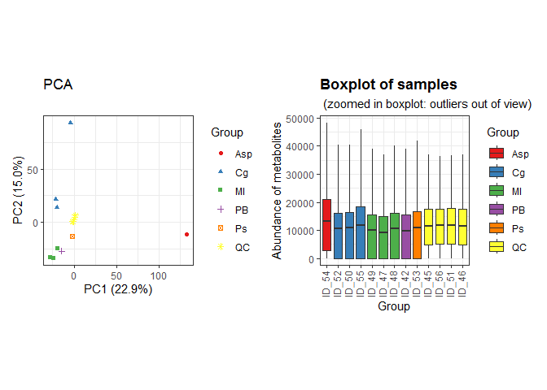

```r
# Data extraction
mode_test <- modes$RP_NEG
# Boxplot of raw data
raw_bp <- plot_sample_boxplots(mode_test,
                               order_by = "Group",
                               fill_by = "Group")
# PCA of raw data
raw_pca <- plot_pca(mode_test,
                       center = TRUE,
                       shape = "Group",
                       color = "Group")
# Package to plots visualization in a same windows
#if (!requireNamespace("devtools", quietly = TRUE)) {
#  install.packages("devtools")
#}
#devtools::install_github("thomasp85/patchwork")
library(patchwork)
# Plot
raw_pca + raw_bp
```

## Preprocessing

The first step of the preprocessing is to change the features with value equal to 0 to NA.

```r
# Data extraction
mode <- modes$RP_NEG
# Change 0 value to NA
mode <- mark_nas(mode, value = 0)
```

Then, features with low detection rate are first flagged and then could be removed. The “notame” package employs two criteria to select this features. First, is the feature presence in a percentage of QC injections, and then the feature presence in a percentage within a sample group or class.

```r
# Low detection rate
mode <- flag_detection(mode, qc_limit = 3/4, group_limit = 0)
```

```
## INFO [2023-12-07 20:10:45]
## 15% of features flagged for low detection rate
```

```r
# Some statistics after low detection algorithm
visualizations(mode, prefix = paste0(ppath, "Figure/LCMS/", "Low_Detection"))
```

With these values, features which that were not detected in 75% of the QC injections will be flagged as low detection rate.

The next step for preprocessing correspond to drift correction. The drift correction can be applied by smoothed cubic spline regression.

```r
# Drift correction
corrected <- correct_drift(mode)
```

```
## INFO [2023-12-07 20:16:41]
## Starting drift correction at 2023-12-07 20:16:41
## INFO [2023-12-07 20:17:03] Drift correction performed at 2023-12-07 20:17:03
## INFO [2023-12-07 20:17:12] Inspecting drift correction results 2023-12-07 20:17:12
## INFO [2023-12-07 20:17:32] Drift correction results inspected at 2023-12-07 20:17:32
## INFO [2023-12-07 20:17:32]
## Drift correction results inspected, report:
## Drift_corrected: 72%,  Missing_QCS: 28%
```

```r
# Flag low quality features
corrected <- flag_quality(corrected)
```

```
## INFO [2023-12-07 20:17:32]
## 35% of features flagged for low quality
```

Then we can visualize the data after drift correction.

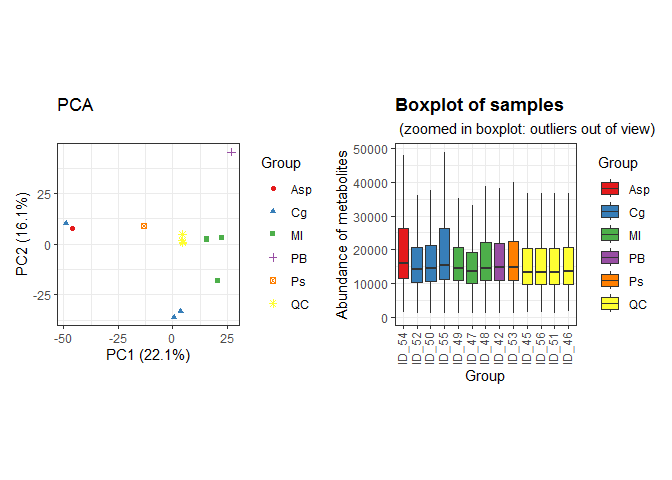

```r
# Boxplot
corr_bp <- plot_sample_boxplots(corrected,
                                      order_by = "Group",
                                      fill_by = "Group")
# PCA
corr_pca <- plot_pca(corrected,
                        center = TRUE,
                        shape = "Group",
                        color = "Group")
# Plot
corr_pca + corr_bp
```

Contaminant peaks based on the process blank will be removed.

```r
# Removal of contaminants
corrected_no_blank <- flag_contaminants(corrected,
                                        blank_col = "Group",
                                        blank_label = "PB",
                                        flag_thresh = 0.8,
                                        flag_label = "Contaminant")
```

```
## INFO [2023-12-07 20:17:34]
## 28% of features flagged as contaminants
```

```r
# Removal blank group from dataset
corrected_no_blank <- corrected_no_blank[, corrected_no_blank$Group != "PB"]
```

```r
# Some statistics after feature blank detection algorithm
visualizations(corrected_no_blank, prefix = paste0(ppath, "Figure/LCMS/", "No_Blank"))
```

The next step is feature clustering. This step helps us reduce the number of features of the same molecule that were split due to ionization behavior (In-source fragmentation for example).

```r
clustered <- cluster_features(corrected_no_blank,
                              rt_window = 1/60,
                              all_features = TRUE,
                              corr_thresh = 0.90,
                              d_thresh = 0.8,
                              plotting = TRUE,
                              prefix = paste0(ppath, "Cluster/LCMS/LCMS_Cluster")
                              )
compressed <- compress_clusters(clustered)
```

We can inspect data after clustering algorithm.

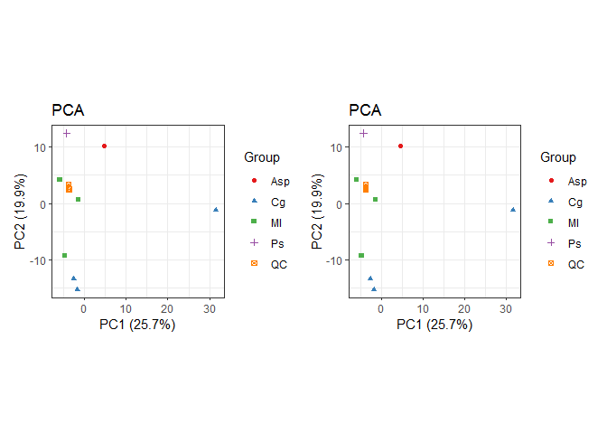

```r
# Boxplot
compr_bp <- plot_sample_boxplots(compressed,
                                 order_by = "Group",
                                 fill_by = "Group")
# PCA
compr_pca <- plot_pca(compressed,
                        center = TRUE,
                        shape = "Group",
                        color = "Group")
# Plot
compr_pca + compr_pca
```

The next step imputes the data.

```r
# To clean data
set.seed(123)
imputed <- impute_rf(compressed)
```

```
## INFO [2023-12-07 21:07:19]
## Starting random forest imputation at 2023-12-07 21:07:19
## INFO [2023-12-07 21:07:28] Out-of-bag error in random forest imputation: 0.449
## INFO [2023-12-07 21:07:28] Random forest imputation finished at 2023-12-07 21:07:28
```

We can inspect PCA plot after imputation.

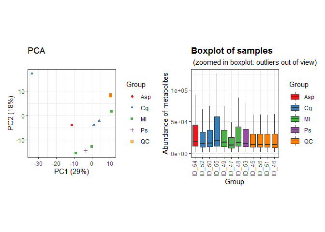

```r
# Boxplot
imp_bp <- plot_sample_boxplots(imputed,
                               order_by = "Group",
                               fill_by = "Group")
# PCA
imp_pca <- plot_pca(imputed,
                    center = TRUE,
                    shape = "Group",
                    color = "Group")
# Plot
imp_pca + imp_bp
```

Finally, the data is ready to be exported and proceed with the statistical analysis.

```r
save(imputed, file = paste0(ppath, "Result/LCMS/Notame_LCMS_output.RData"))
```

# PCA plots

Droping flagged features

```r
# Extract clean data
no_flag <- drop_flagged(imputed)

# Extracting feature height table
peak_height <- exprs(no_flag)
# Extracting samples information
pheno_data <- no_flag@phenoData@data
# Extracting feature information
feat_data <- no_flag@featureData@data
```

Preparing data and transposing feature table.

```r
# Transposing feature height table
transp_table  <- t(peak_height)
# Changing NA to 0
transp_table[is.na(transp_table)]=0
# Centering and Scaling features
neg_pca <- prcomp(transp_table, center = TRUE, scale. = TRUE)
```

Plotting PCA results.

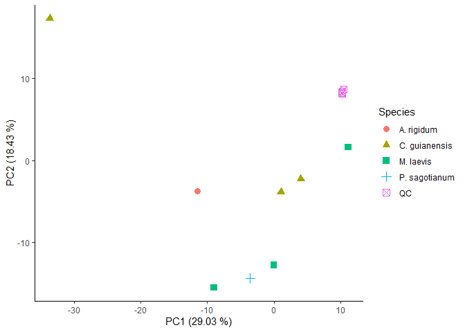

```r
# Library to left_join use
library(dplyr)
# PCA scores
scores <- neg_pca$x %>%                  # Get PC coordinates
  data.frame %>%                         # Convert to data frames
  mutate(Sample_ID = rownames(.)) %>%    # Create a new column with the sample names
  left_join(pheno_data )                 # Adding metadata
# PCA plot
ggplot(scores,
       aes(PC1, PC2, shape = Species, color = Species)) +
  geom_point(size = 3) +
  guides(x=guide_axis(title = "PC1 (29.03 %)"),
         y=guide_axis(title = "PC2 (18.43 %)")) +
  theme_classic()
```

```r
# Save plot
ggsave("Result/LCMS/LCMS_PCA.png", width = 5, height = 4, device='png', dpi="print")
```

Plotting loading results.

```r
loadings <- neg_pca$rotation %>%           # Extract loadings
  data.frame(Cluster_ID = rownames(.))     # New column with feature name
```

Creating an artificial table with feature ID and compound name column.

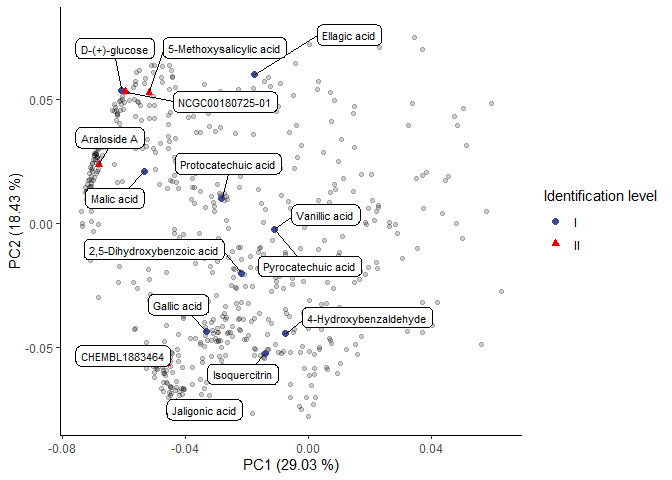

```r
# Exporting notame output to find and filter identified metabolites
write_to_excel(clustered, "Result/LCMS/Clustered_features.xlsx")
# Load a metabolite name table
metab_name <- readxl::read_excel("Data/LCMS_Metabolites.xlsx", 1)
# Creating a new small table of the annotated compounds
neg_compouds <- left_join(metab_name, loadings)
# Plotting results
ggplot(loadings, aes(PC1, PC2)) +
  geom_point(alpha = 0.2) +
  theme_classic() +
  geom_point(data = neg_compouds,
             aes(shape = `Identification level`, color = `Identification level`),
             size = 2) +
  ggrepel::geom_label_repel(data = neg_compouds,
                            aes(label = Metabolite_name),
                            box.padding = 0.8,
                            label.padding = 0.3,
                            label.r = 0.3,
                            cex = 3) +
  guides(x=guide_axis(title = "PC1 (29.03 %)"),
         y=guide_axis(title = "PC2 (18.43 %)")) +
  ggsci::scale_color_aaas()
```

```r
# Save plot
ggsave('Result/LCMS/LCMS_Loadings.png', width = 10, height = 6, device='png', dpi="print")
```

# Heat map plot

ComplexHeatmap package and dependency installation.

```r
# ComplexHeatmap package installation
#if (!requireNamespace("BiocManager", quietly=TRUE))
#    install.packages("BiocManager")
#BiocManager::install("ComplexHeatmap")
library(ComplexHeatmap)

# ColorRamp2 package installation
#if (!requireNamespace("devtools", quietly = TRUE)) {
#  install.packages("devtools")
#}
#devtools::install_github("jokergoo/colorRamp2")
library(colorRamp2)

# Cowplot package installation
#install.packages("cowplot")
library(cowplot)
```

Extracting and loaded of identified metabolites abundance.

```r
# Exporting "notame" output to find and filter height of identified metabolites
write_to_excel(no_flag, "Result/LCMS/no_flag_features.xlsx")
```

```
## INFO [2023-12-07 21:07:36] Moved Datafile column to last to get meaningful column names for abundances
```

```r
# Metabolite name table
metab_name_hm <- readxl::read_excel("Data/LCMS_Metabolite_HeatMap.xlsx", 2)
# Logarithmic scale
hm_scl <- metab_name_hm[, 6:9] %>% as.matrix %>% log10()
rownames(hm_scl) <- metab_name_hm$Metabolite_name
# Metabolite classification
metab_class <- metab_name_hm %>% select(Superclass, Metabolite = Metabolite_name)
# Metabolite class to HeatMap anotation
met_class_annotation <-  metab_class %>% select(Superclass) %>%
  as.matrix()
rownames(met_class_annotation) <- metab_class$Metabolite
# Top information
top_info <- data.frame(Species = c( rep("A. rigidum"),
                                    rep("C. guianensis"),
                                    rep("M. laevis"),
                                    rep("P. sagotianum")))
rownames(top_info) <- paste(top_info$Species, rep(c(1, 2, 3, 4)))
top_info <- as.matrix(top_info)
```

Scaling, row and top heatmap anotation.

[figure not shown]

```r
set.seed(2024)
# Metabolite class color
cols_metclass <- c("Benzenoids" = "#800000FF",
                   "Organic oxygen compounds" = "#8A9045FF",
                   "Lipids and lipid-like molecules" = "#FFA319FF",
                   "Phenylpropanoids and polyketides" = "#FF5A5A",
                   "Organic acids and derivatives" = "#155F83FF")
# Add row anotation to HeatMap
hm_row_ann <- rowAnnotation(Metabolite = met_class_annotation,
                            col = list(Metabolite = cols_metclass),
                            show_annotation_name = T,
                            show_legend=F)
# Species color
cols_species <- c("A. rigidum" = "#e6550d",
                 "C. guianensis" = "#91cf60",
                 "M. laevis" = "#33d2ff",
                 "P. sagotianum" = "#d957f8")
# Add top anotation to HeatMap
top_info_ann <- HeatmapAnnotation(`Species` = top_info,
                                  col = list(`Species` = cols_species),
                                  show_annotation_name = T,
                                  show_legend=F,
                                  border = TRUE)
# Color scale
mycol <- colorRamp2(c(3, 5, 7),
                    c("blue", "white", "red"))
# Heatmap matrix plotting
hm_plot <- Heatmap(hm_scl,
        col = mycol,
        border_gp = grid::gpar(col = "black", lty = 0.05),
        rect_gp = grid::gpar(col = "black", lwd = 0.75),
        clustering_distance_columns = "euclidean",
        clustering_method_columns = "complete",
        top_annotation = top_info_ann,
        right_annotation = hm_row_ann,
        show_heatmap_legend = F,
        row_km = 3, column_km = 2)
hm_plot
```

Adding legends to heatmap.

```r
# Color scale legend
lgd1 <- Legend(col_fun = mycol,
               title = "log10 abundance",
               at = seq(7),
               direction = "horizontal" )
# Plants species legend
lgd2 <- Legend(labels = gt_render(c("*A. rigidum*",
                                    "*C. guianensis*",
                                    "*M. laevis*",
                                    "*P. sagotianum*")),
               legend_gp = gpar(fill = cols_species),
               title = "Plant species", ncol = 1)
# Metabolite class Legend
lgd3 <- Legend(labels = c(unique(metab_class$Superclass)),
               legend_gp = gpar(fill = cols_metclass),
               title = "Metabolite superclass", ncol = 2)
```

ComplexHeatmap plot

[figure not shown]

```r
set.seed(2024)
# Converting to ggplot
gg_heatmap <- grid.grabExpr(draw(hm_plot))
gg_heatmap <- ggpubr::as_ggplot(gg_heatmap)
# Legends
all_legends <- packLegend(lgd1, lgd2, lgd3, direction = "horizontal")
gg_legend <- grid.grabExpr(draw(all_legends))
gg_legend_fn <- ggpubr::as_ggplot(gg_legend)
# Heatmap plot
gcms_hm <- plot_grid(gg_legend_fn,
          gg_heatmap, ncol = 1,
          rel_heights = c(0.857, 4))
gcms_hm
```

```r
# Save heatmap plot
ggsave(filename = "Result/LCMS/LCMS_Heatmap.jpeg", plot = gcms_hm,
      width = 5, height = 4, units = "in", dpi = 300, scale = 1.7)
```

Finish a record.

```r
finish_log()
```

[output not shown]